# RahulBurjanroppaProject_Full_Code_Notebook_EasyVisa

[figure not shown]

Artificial Intelligence and Machine Learning

Ensemble Techniques and Model Tuning

[figure not shown]

Visa Approval Facilitation

# **Exploratory Data Analysis**

## **Importing necessary libraries**

```python
import numpy as np
import pandas as pd
import matplotlib.pyplot as plt
import seaborn as sns

from sklearn.model_selection import train_test_split, cross_val_score, GridSearchCV
from sklearn.tree import DecisionTreeClassifier, plot_tree
from sklearn.metrics import accuracy_score, precision_score, recall_score, confusion_matrix, classification_report, f1_score, roc_auc_score
from sklearn.tree import export_text
from sklearn.preprocessing import StandardScaler
from sklearn.ensemble import RandomForestClassifier, BaggingClassifier, AdaBoostClassifier, GradientBoostingClassifier
from imblearn.over_sampling import SMOTE
from imblearn.under_sampling import RandomUnderSampler
```

## **Problem Definition**

American companies are depending more and more on foreign talent to fill labor shortages in a variety of areas. The Office of Foreign Labor Certification (OFLC) is in charge of reviewing an increasing number of visa applications annually to ascertain if firms may engage foreign workers without negatively affecting the pay or working conditions of American workers. It takes more time and resources to carefully evaluate every case as the number of applications keeps growing.

The goal of this project is to create a machine learning-based classification model that forecasts whether a visa application will be approved or rejected based on employer and applicant attributes like employment region, education level, job experience, prevailing wage, and company size. This methodology seeks to help decision-makers prioritize applications with a better chance of acceptance and indicate situations that might need more examination by identifying the critical elements that affect visa approval decisions.

From a business standpoint, the solution may shorten processing times, increase operational effectiveness, and offer data-driven insights into the profiles most likely to be certified for a visa. In order to ensure that the model promotes fair and informed decision-making rather than taking the place of human judgment, the final model is assessed using a variety of performance measures, with a focus on recall and overall prediction dependability.

## **Loading the Dataset**

#### **The dataset is as follows**

```python
df = pd.read_csv('EasyVisa.csv')
print("The first few columns of the dataset: ")
df.head(5)
```

```
The first few columns of the dataset:
```

|  | case_id | continent | education_of_employee | has_job_experience | requires_job_training | no_of_employees | yr_of_estab | region_of_employment | prevailing_wage | unit_of_wage | full_time_position | case_status |
| --- | --- | --- | --- | --- | --- | --- | --- | --- | --- | --- | --- | --- |
| 0 | EZYV01 | Asia | High School | N | N | 14513 | 2007 | West | 592.2029 | Hour | Y | Denied |
| 1 | EZYV02 | Asia | Master's | Y | N | 2412 | 2002 | Northeast | 83425.6500 | Year | Y | Certified |
| 2 | EZYV03 | Asia | Bachelor's | N | Y | 44444 | 2008 | West | 122996.8600 | Year | Y | Denied |
| 3 | EZYV04 | Asia | Bachelor's | N | N | 98 | 1897 | West | 83434.0300 | Year | Y | Denied |
| 4 | EZYV05 | Africa | Master's | Y | N | 1082 | 2005 | South | 149907.3900 | Year | Y | Certified |

```python
print("The size & columns of the dataset: ")
df.shape, df.info()
```

```
The size & columns of the dataset:
<class 'pandas.core.frame.DataFrame'>
RangeIndex: 25480 entries, 0 to 25479
Data columns (total 12 columns):
 #   Column                 Non-Null Count  Dtype
---  ------                 --------------  -----
 0   case_id                25480 non-null  object
 1   continent              25480 non-null  object
 2   education_of_employee  25480 non-null  object
 3   has_job_experience     25480 non-null  object
 4   requires_job_training  25480 non-null  object
 5   no_of_employees        25480 non-null  int64
 6   yr_of_estab            25480 non-null  int64
 7   region_of_employment   25480 non-null  object
 8   prevailing_wage        25480 non-null  float64
 9   unit_of_wage           25480 non-null  object
 10  full_time_position     25480 non-null  object
 11  case_status            25480 non-null  object
dtypes: float64(1), int64(2), object(9)
memory usage: 2.3+ MB
```

```
((25480, 12), None)
```

```python
print("The statistical summary of the dataset: ")
df.describe()
```

```
The statistical summary of the dataset:
```

|  | no_of_employees | yr_of_estab | prevailing_wage |
| --- | --- | --- | --- |
| count | 25480.000000 | 25480.000000 | 25480.000000 |
| mean | 5667.043210 | 1979.409929 | 74455.814592 |
| std | 22877.928848 | 42.366929 | 52815.942327 |
| min | -26.000000 | 1800.000000 | 2.136700 |
| 25% | 1022.000000 | 1976.000000 | 34015.480000 |
| 50% | 2109.000000 | 1997.000000 | 70308.210000 |
| 75% | 3504.000000 | 2005.000000 | 107735.512500 |
| max | 602069.000000 | 2016.000000 | 319210.270000 |

## **Univirate Analysis**

For this analysis, a countplot will be used to depict the categorical value "Case Status" from within the dataset to derive insight. Univariate analysis helps identify skewness, imbalance, and dominant categories that may influence downstream modeling decisions.

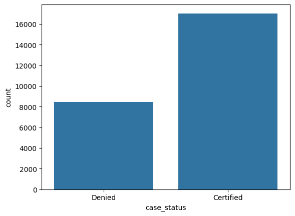

```python
sns.countplot(x="case_status", data=df)
```

## **Numerical Variables**

The numerical variables in the dataset were analyzed to understand their distribution, spread, and potential impact on visa certification outcomes. Visualizations such as histograms and box plots were used to identify patterns, skewness, and the presence of outliers. Understanding these characteristics is essential for selecting appropriate preprocessing techniques and ensuring robust model performance.

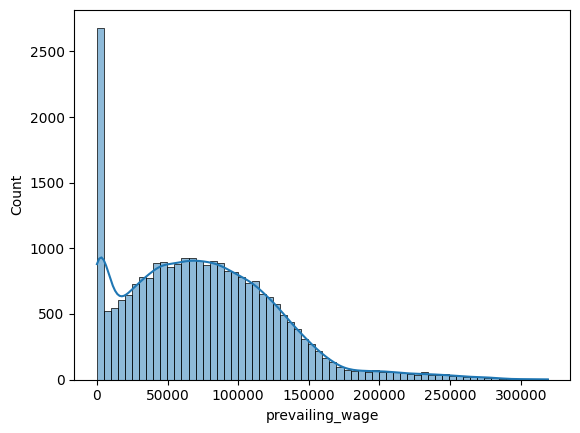

```python
sns.histplot(df["prevailing_wage"], kde=True)
```

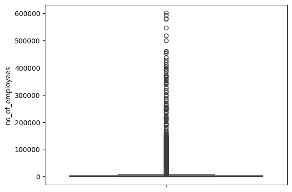

```python
sns.boxplot(df["no_of_employees"])
```

The prevailing wage distribution is right-skewed, with most applications concentrated in the lower to mid-wage range and a small number of high-wage outliers, indicating that while most roles offer moderate compensation, a few specialized positions command significantly higher wages. The number of employees variable also exhibits strong right skewness with numerous outliers, reflecting a wide variation in employer size from small firms to very large organizations. These patterns suggest that both variables capture meaningful economic differences among applications and may significantly influence visa approval decisions, while also requiring careful handling during modeling to account for skewness and extreme values.